← Back

# Assignment 2: Redesigning the Nightingale Coxcomb

**Notebook-based redesign of Florence Nightingale's classic polar area chart**

This visualization redesigns Nightingale's famous 1858 "Rose Diagram" that illustrated causes of mortality during the Crimean War. The original polar area chart was revolutionary for its time. This notebook explores alternative representations of the same data.

# Redesigning Florence Nightingale's Rose Diagram

## The Original Graphic (1858)

[figure not shown]

Florence Nightingale created this polar area diagram (often called the "Rose Diagram" or "Coxcomb") to illustrate the causes of mortality among British soldiers during the Crimean War (1854–1856). Her goal was to convince military and government officials that most deaths were preventable, caused by disease rather than battle wounds.

### Reading the Original

- **Blue wedges**: Deaths from preventable diseases (cholera, typhus, dysentery)
- **Red wedges**: Deaths from battle wounds
- **Black wedges**: Deaths from all other causes

Each wedge represents one month, with the area proportional to the death count. The diagram is split into two charts: April 1854–March 1855 (right) and April 1855–March 1856 (left).

### Why Redesign?

While revolutionary for its time, the polar format has limitations:

1. **Difficult comparisons:** Areas in polar charts are harder to compare than linear bars
2. **No common baseline:** Each wedge starts from the center, making precise comparison challenging
3. **Split visualization:** The two-chart layout interrupts the timeline narrative
4. **Missing context:** Army size fluctuated significantly, affecting interpretation of raw death counts

## My Redesign Approach

I chose a **stacked bar chart with dual y-axes** to address these issues:

- **Stacked bars** show absolute death counts by cause, preserving Nightingale's original color scheme (blue for disease, red for wounds, grey for other)
- **Line overlay** shows death *rates* per 1,000 soldiers, accounting for army size changes
- **Linear timeline** makes month-to-month trends immediately visible
- **Single unified chart** tells the complete story without splitting the data

## Exploring the Data

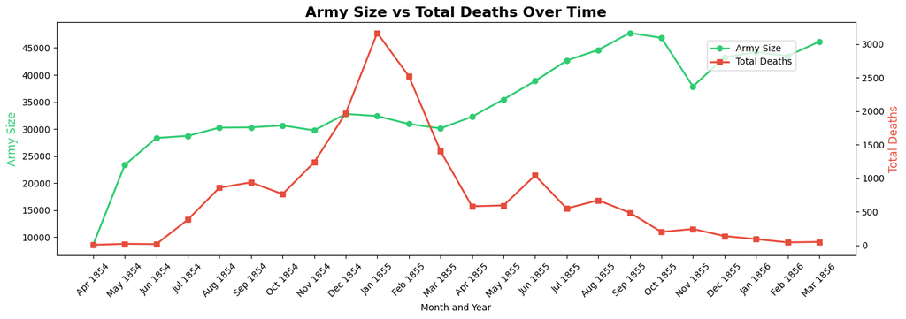

## The Redesigned Visualization

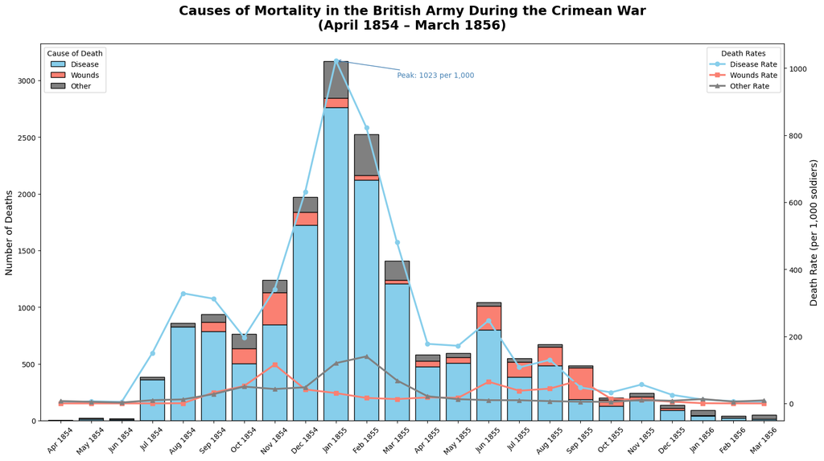

## Key Insights

Nightingale's advocacy for improved sanitation, clean water, and proper ventilation in military hospitals saved countless lives, a message this redesign aims to communicate even more powerfully than the original.